# Exploratory data analysis report

for collagen diseases dataset

Author

Affiliation

Xiaojing Ni

Georgetown University

Published

February 20, 2023

## 1 Introduction

The overall objective of this study is to study potential factors helping to detect and predict thrombosis, one of the severe complications cased by collagen diseases. This report contains the preliminary results of the exploratory data analysis on the University hospital datasets. The dataset contains users’ information, such as sex, date of birth, and date comes to hospital, special examination results of users’ having thrombosis, and general laboratory examination results.

In this report, the main objective is to understand the dataset using basic statistics and visualizations. This will help to determine the potential analysis and research directions of the mechanisms of the collagen diseases and their complications. Specifically, this report explore high-risk people group and if special laboratory examination indeed have special purpose.

## 2 Method and material

The method used to generate this report include statistics and data manipulation and visualizations. The tool used to generate the results is python (matplotlib package for visualization) and Visual Studio Code. More detailed methods can be found in the EDA.html.

## 3 Results and discussion

### 3.1 Young people can also be high-risk.

Figure 1 shows the distribution of thrombosis patients through out ages. Surprisingly, thrombosis is not exclusively for elder people. For people who have been diagnosed with thrombosis, young people, age less than 30, are also high-risk to thrombosis. Figure 1 shows that for severe thrombosis (level 2), many of people is having thrombosis before their 30’s. This is also true for not severe thrombosis. Thus, younger people also need to be aware of their health conditions, especially if they are at high risk for thrombosis, which will be discussed in next session.

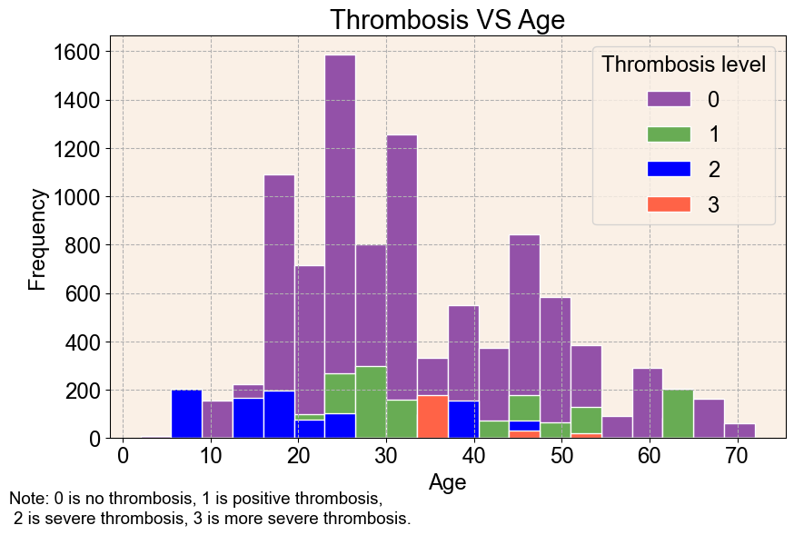

Figure 1: Number of thrombosis patients of various thrombosis levels through out different ages. Most people do not have thrombosis (purple bars). The severe thrombosis (level 2 with blue bars) happens in young age, while the most severe thrombosis happens after 30.

### 3.2 Who is high-risk?

Figure 2 shows the most diagnosis with thrombosis positive. For example, 59% of the thrombosis positive patient also have SLE. If people with those syndrome or disorder, they can be considered as high-risk for thrombosis. The top three diagnosis are Systemic Lupus Erythematosus (SLE), Antphospholipid syndrome (APS), and Stevens-Johnson syndrome (SjS). One interesting finding is that susp, an abbreviation of suspect is related to negative thrombosis, which implies that many suspect diagnosis, i.e. SLE suspected, turns out to be potential negative diagnosis.

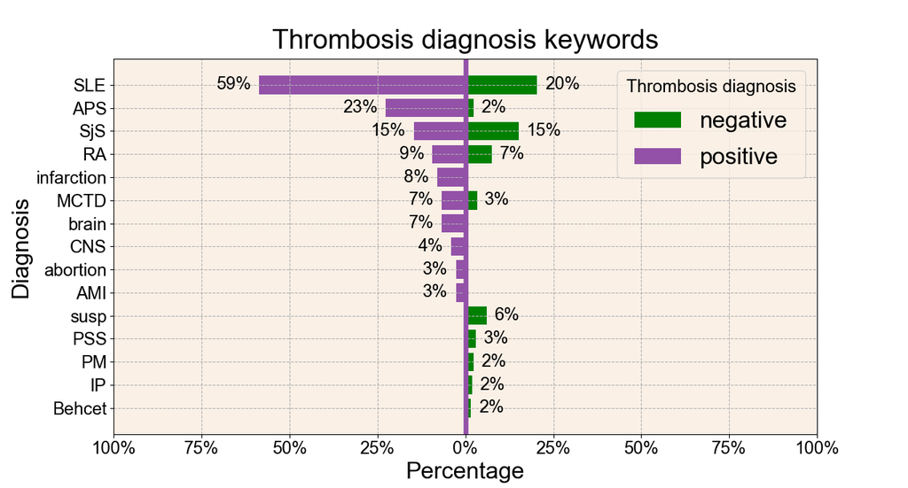

Figure 2: Diagnosis comparison of thrombosis negative and positive patients. Systemic Lupus Erythematosus (SLE) is one of the most diagnosis of positive patients. As well as Antphospholipid syndrome (APS). People with those diagnosis have higher risk of thrombosis.

The blood test results can also imply the high-risk people group. Figure 3 shows the general laboratory examination results and thrombosis relationship. The focus of the figure is to look at those abnormal index and thrombosis. For example, the black boxes indicate that when total protein (TP), albumin(ALB), blood glucose (GLU), Red blood cells(RBC) are abnormal, the thrombosis is positive and with severe level. Thus, people with those index abnormal are potentially considered as high-risk for thrombosis.

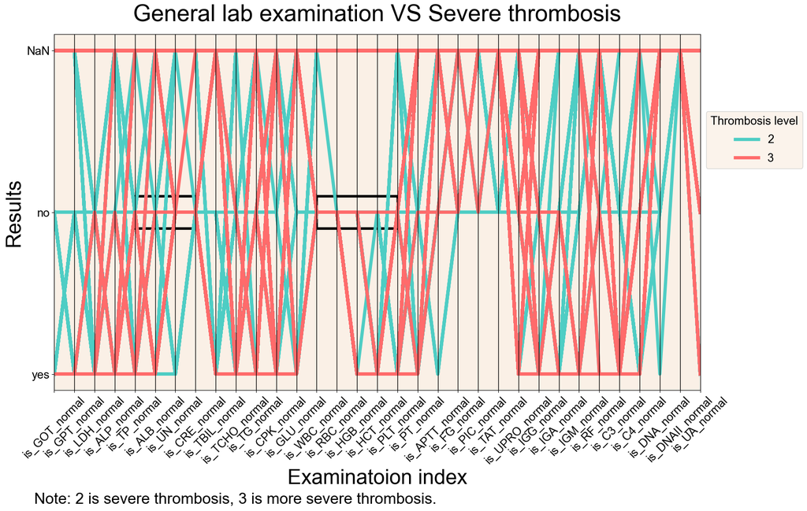

Figure 3: General examination and severe thrombosis. The total protein (TP), albumin(ALB), blood glucose (GLU), Red blood cells(RBC) (in black boxes) abnormal can imply the high risks of thrombosis.

### 3.3 Want to do less blood test?

The answer is no. After people are determined as high-risk people group, or already have thrombosis, they need to seek doctors’ help. Special laboratory examination can be used to determine further treatment plan. Figure 4 shows the correlations among the index in special laboratory examinations. Most of the index have small correlations. This imply that they are used for different testing purpose and cannot replaced each other. However, there are some correlation in the data. For example, activated partial prothrombin time (APTT) and prothrombin time (PT) has high negative correlation. FG and APTT also has correlation. If we want to do further analysis on the numerical value of those measurements, these correlations need to be considered.

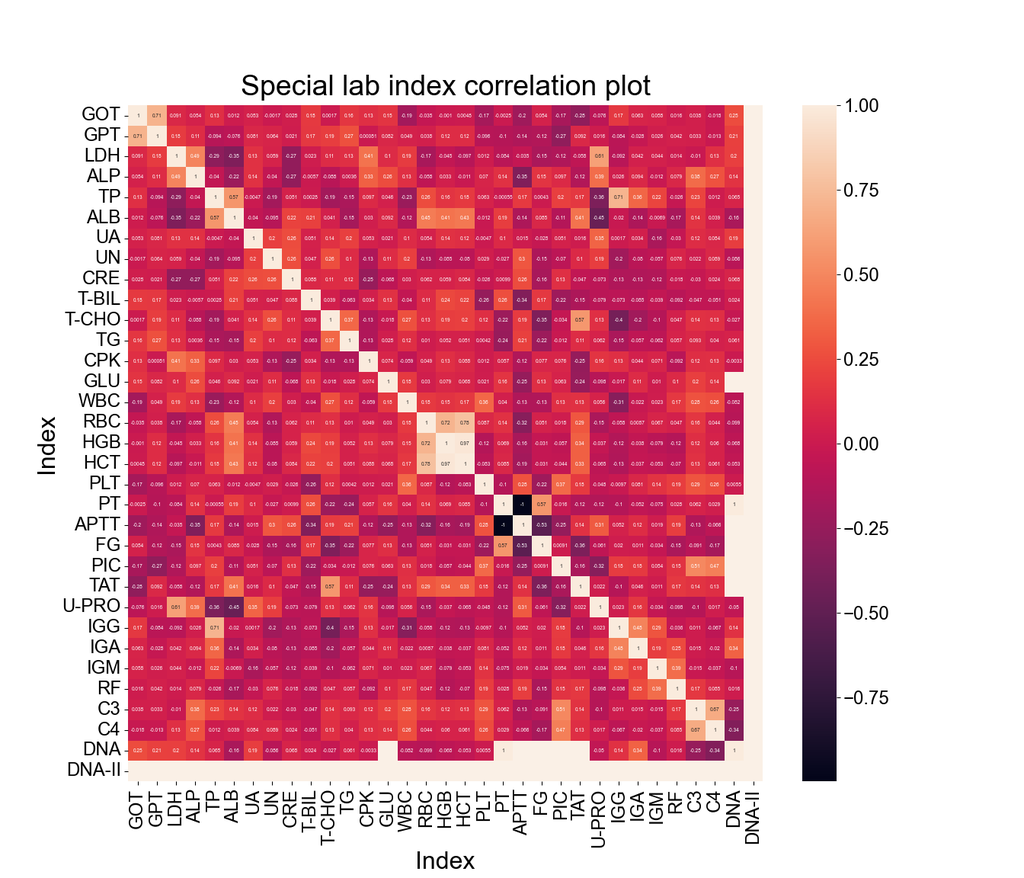

## 4 Conclusion

This report explores the high-risk people for thrombosis. First, young people should also be careful with thrombosis, especially when if they have some other diagnosis like SLE and APS. People with abnormal blood test on index such as GLU, ALB, and RBC should also ask doctors’ advice, as they will do other special laboratory examination to determine the treatment plan with already-minimum blood test.

## 5 Appendix

The analysis and data can be found in Github repo: https://github.com/XiaojingNi/collagen_diseases_eda

Table 1: Terminology

| Term | Description |
| --- | --- |
| GOT | AST glutamic oxaloacetic transaminase (N < 60) |
| GPT | ALT glutamic pylvic transaminase (N < 60) |
| LDH | lactate dehydrogenase (N < 500) |
| ALP | alkaliphophatase (N < 300) |
| TP | total protein (6.0 < N < 8.5) |
| ALB | albumin (3.5 < N < 5.5) |
| UA | uric acid (N > 8.0 (Male) N > 6.5 (Female)) |
| UN | urea nitrogen (N > 30 ) |
| CRE | creatinine (N > 1.5) |
| T-BIL | total bilirubin (N < 2.0) |
| T-CHO | total cholesterol (N < 250 ) |
| TG | triglyceride (N < 200) |
| CPK | creatinine phosphokinase (N < 250) |
| GLU | blood glucose (N < 180) |
| WBC | White blood cell (3500 < N < 9000 ) |
| RBC | Red blood cell (350 < N < 600 ) |
| HGB | Hemoglobin (10 < N < 17) |
| HCT | Hematoclit (29 < N < 52) |
| PLT | platelet (100 < N < 400 ) |
| PT | prothrombin time (N < 14) |
| APTT | activated partial prothrombin time (N < 45) |
| FG | fibrinogen (150 < N < 450) |
| PIC | plasmininhibitor-plasmin complex (N < 0.8) |
| TAT | thrombin-antithrombin III complex (N < 3.0) |
| U-PRO | proteinuria (0 < N 30) |
| IGG | Ig G (900 < N < 2000 ) |
| IGA | Ig A (80 < N < 500) |
| IGM | Ig M (40 < N < 400) |
| RF | RAHA (N < 20) |
| C3 | complement 3 (N > 35 ) |
| C4 | complement 4( N > 10 ) |
| DNA | anti-DNA (N < 8 ) |
| DNA-II | anti-DNA (N < 8 ) |